# Labyrinthes

Nous allons nous intéresser aux labyrinthes, pour celà nous allons nous concentrer sur plusieurs notions :

- Nous voulons pouvoir créer des labyrinthes carrés de manière rapide, aléatoire et de sorte que le labyrinthe soit faisable mais pas trop simple.
- Nous voulons pouvoir créer des labyrinthes circulaire (comme les jeux sur les boites de céréales).
- Nous voulons pouvoir résoudre ces labyrinthes.
- Nous voulons pouvoir résoudre un labyrinthe à partir d'une photo.

Commençons par le début, importons tous les packages dont nous auront besoin tout du long.

```python
import numpy as np
import random as rd
import matplotlib.pyplot as plt
import copy
import cv2
```

## 1.Generation des labyrinthes carrés

On va symboliser nos labyrinthes de taille n x n par des matrices n x n. Puis on va procéder comme dans la méthode expliqué sur cette page : [wikipedia](https://fr.wikipedia.org/wiki/Mod%C3%A9lisation_math%C3%A9matique_de_labyrinthe#Algorithmes_de_construction_de_labyrinthes)

On définit d'abord la taille de nos labyrinthes.

```python
maze_size = 13
if maze_size%2 == 0:
    maze_size += 1
```

Puis on définit une fonction pour créer la base de nos labyrinthes, c'est à dire des labyrinthes vides.

```python
def empty_maze(n,m):
    M = []
    for k in range(n):
        M.append([0]*m)
    return M

M_test = empty_maze(maze_size,maze_size)
print(np.array(M_test))
```

```
[[0 0 0 0 0 0 0 0 0 0 0 0 0]
 [0 0 0 0 0 0 0 0 0 0 0 0 0]
 [0 0 0 0 0 0 0 0 0 0 0 0 0]
 [0 0 0 0 0 0 0 0 0 0 0 0 0]
 [0 0 0 0 0 0 0 0 0 0 0 0 0]
 [0 0 0 0 0 0 0 0 0 0 0 0 0]
 [0 0 0 0 0 0 0 0 0 0 0 0 0]
 [0 0 0 0 0 0 0 0 0 0 0 0 0]
 [0 0 0 0 0 0 0 0 0 0 0 0 0]
 [0 0 0 0 0 0 0 0 0 0 0 0 0]
 [0 0 0 0 0 0 0 0 0 0 0 0 0]
 [0 0 0 0 0 0 0 0 0 0 0 0 0]
 [0 0 0 0 0 0 0 0 0 0 0 0 0]]
```

### On va ensuite suivre ce qu'on voulait faire (voir : [ici](https://fr.wikipedia.org/wiki/Mod%C3%A9lisation_math%C3%A9matique_de_labyrinthe#Algorithmes_de_construction_de_labyrinthes)) :

Pour qu'un labyrinthe soit résoluble il suffit qu'il ne possède qu'une seule composante connexe, ainsi toutes les cases du labyrinthe seront accessibles, donc on sera sur d'avoir une solution. En plus certaines cases n'auront pas besoin d'être exploré pour résoudre le labyrinthe, elle participeront à faire des fausses pistes dans le labyrinthe.

On va donc pour ce faire placer des valeurs dans chaque cases d'un pavage dans notre labyrinthe :

```python
def colorize_maze(M):
    n_color = 1
    for i in range(len(M)):
        for j in range(len(M[0])):
            if (i%2 == 1 and j%2 == 1):
                M[i][j] = n_color
                n_color += 1

colorize_maze(M_test)
```

Puis on va également introduire une manière plus jolie de regarder nos labyrinthes :

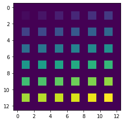

```python
plt.imshow(M_test)
```

Ensuite nous allons casser des murs à notre labyrinthe tant qu'il n'est pas connexe.

Pour celà on choisit un mur :

- si des deux côtes il y a le même nombre c'est que c'est la même composante, on le laisse.
- si par contre les nombres sont differents on le casse et on remplace la composante du plus grand nombre par la valeur du plus petit. Et on répète celà tant que toutes les cases ne sont pas strictement plus petite que 2.

On commence par définir des fonctions qui nous seront utiles :

```python
def still_case_over2(M):
    for i in range(1,len(M)-1,2):
        for j in range(1,len(M[0])-1,2):
            if M[i][j] > 1:
                return True
    return False

def get_values_around_case(i,j,M):
    N = []
    for voisin in [(i-1,j),(i+1,j),(i,j-1),(i,j+1)]:
        u,v = voisin
        if (M[u][v] != 0):
            N.append(M[u][v])
    return sorted(N)

def replace_all_by(old_nb,new_nb,M):
    for i in range(len(M)):
        for j in range(len(M[0])):
            if M[i][j] == old_nb:
                M[i][j] = new_nb

def wall_of_maze(M):
    W = []
    for i in range(1,len(M)-1):
        for j in range(1+(i%2),len(M[0])-1,2):
            W.append((i,j))
    return W
```

Et enfin on fait marcher le tout :

(la partie "breaks" est une option si l'on veut casser quelques murs pour avoir plusieurs solutions et rendre le labyrinthe un poil plus complexe)

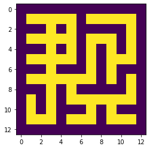

```python
def color_to_maze(M,breaks=True):
    walls = wall_of_maze(M)
    while(still_case_over2(M)):
        r = rd.randint(0, len(walls)-1)
        i,j = walls[r]
        values = get_values_around_case(i,j,M)
        if values[0] != values[-1]:
            replace_all_by(values[-1],values[0],M)
            M[i][j] = values[0]
        walls = walls[:r]+walls[r+1:]

    if breaks:
        for k in range(min(len(M),len(M[0]),len(walls)//4)):
            r = rd.randint(0, len(walls)-1)
            i,j = walls[r]
            M[i][j] = 1
            walls = walls[:r]+walls[r+1:]

color_to_maze(M_test)
plt.imshow(M_test)
```

Puis on empile les ingredients pour faire notre générateur :

```python
def create_square_maze(n,m,breaks=True):
    if n%2 == 0:
        n += 1
    if m%2 == 0:
        m += 1
    new_M = empty_maze(n,m)
    colorize_maze(new_M)
    color_to_maze(new_M,breaks)
    return new_M
```

```
CPU times: user 80.4 ms, sys: 25 µs, total: 80.4 ms
Wall time: 79.9 ms
```

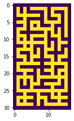

```python
%%time
M2 = create_square_maze(31,17)
plt.imshow(M2)
```

On peut rajouter un petit détail héstéthique :

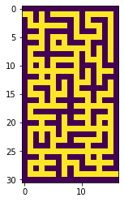

```python
L = copy.deepcopy(M2)
L[1][0] = 1
L[-2][-1] = 1

plt.imshow(L)
```

## 2.Resolution de labyrinthe

Maintenant on va s'intéresser à la méthode de résolution de notre labyrinthe.

Pour cela on va tout d'abord parcourir une fois chaque cases depuis l'origine pour mettre dans chaque case accessible sa distance à l'origine, et on va faire ça jusqu'à trouver notre point d'arriver.

On utilise pour celà un parcours en largeur de "l'arbre des points accessibles".

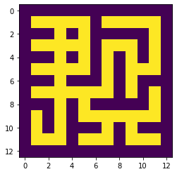

```python
N = copy.deepcopy(M_test)
plt.imshow(N)
```

```python
start = (1,1)
end = (len(N)-2,len(N)-2)
```

```python
N
```

```
[[0, 0, 0, 0, 0, 0, 0, 0, 0, 0, 0, 0, 0],
 [0, 1, 1, 1, 1, 1, 0, 1, 1, 1, 1, 1, 0],
 [0, 0, 0, 1, 0, 1, 0, 0, 0, 0, 0, 1, 0],
 [0, 1, 1, 1, 1, 1, 0, 1, 1, 1, 0, 1, 0],
 [0, 0, 0, 1, 0, 1, 0, 1, 0, 1, 0, 1, 0],
 [0, 1, 1, 1, 1, 1, 0, 1, 0, 1, 1, 1, 0],
 [0, 0, 0, 1, 0, 0, 0, 1, 0, 1, 0, 0, 0],
 [0, 1, 1, 1, 1, 1, 1, 1, 0, 1, 0, 1, 0],
 [0, 0, 0, 1, 0, 1, 0, 0, 0, 0, 0, 1, 0],
 [0, 1, 0, 1, 0, 1, 1, 1, 1, 1, 1, 1, 0],
 [0, 1, 0, 1, 0, 0, 0, 1, 0, 1, 0, 0, 0],
 [0, 1, 1, 1, 0, 1, 1, 1, 0, 1, 1, 1, 0],
 [0, 0, 0, 0, 0, 0, 0, 0, 0, 0, 0, 0, 0]]
```

```python
def travel_maze_for_distance(start,end,N):
    case_to_visit = [[start]]
    distance = 1

    while not(end in case_to_visit[distance-1]):
        distance += 1
        tmp = []
        for coords in case_to_visit[distance-2]:
            i,j = coords
            N[i][j] = distance
            for voisin in [(i-1,j),(i+1,j),(i,j-1),(i,j+1)]:
                a,b = voisin
                if N[a][b] == 1:
                    tmp.append(voisin)
        case_to_visit.append(tmp)

travel_maze_for_distance(start,end,N)
```

```
[[ 0  0  0  0  0  0  0  0  0  0  0  0  0]
 [ 0  2  3  4  5  6  0  1  1  1  1  1  0]
 [ 0  0  0  5  0  7  0  0  0  0  0  1  0]
 [ 0  8  7  6  7  8  0 18 19 20  0  1  0]
 [ 0  0  0  7  0  9  0 17  0 21  0  1  0]
 [ 0 10  9  8  9 10  0 16  0  1  1  1  0]
 [ 0  0  0  9  0  0  0 15  0  1  0  0  0]
 [ 0 12 11 10 11 12 13 14  0  1  0  1  0]
 [ 0  0  0 11  0 13  0  0  0  0  0 21  0]
 [ 0 18  0 12  0 14 15 16 17 18 19 20  0]
 [ 0 17  0 13  0  0  0 17  0 19  0  0  0]
 [ 0 16 15 14  0 20 19 18  0 20 21  1  0]
 [ 0  0  0  0  0  0  0  0  0  0  0  0  0]]
```

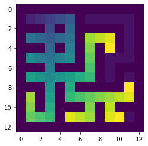

```python
plt.imshow(N)
print(np.array(N))
```

On va maintenant partir de la case de fin et parcours le labyrinthe à l'envers en suivant à chaque fois le voisin qui a la distance la plus faible et on trouvera ainsi un chemin.

(On aurait pu faire la détermination du chemin par récurrence, ce qui n'est pas la meilleure idée en python mais bon, au moins c'est joli)

```python
def get_chemin(start,end,N):
    way = [end]
    i,j = end
    ## On aura besoin d'une fonction auxiliaire pour se débarrasser des cases de valeur 1 et 0
    def aux_chemin(a):
        if a[1] == 0 or a[1] == 1:
            return len(N)**5
        else:
            return a[1]
    ##
    while N[i][j] != 2:
        voisins = [[(i-1,j),N[i-1][j]],[(i+1,j),N[i+1][j]],[(i,j-1),N[i][j-1]],[(i,j+1),N[i][j+1]]]
        next_case = (sorted(voisins,key=aux_chemin))[0][0]
        way.append(next_case)
        i,j = next_case

    return (way+[start])

C = get_chemin(start,end,N)
```

```python
C
```

```
[(11, 11),
 (11, 10),
 (11, 9),
 (10, 9),
 (9, 9),
 (9, 8),
 (9, 7),
 (9, 6),
 (9, 5),
 (8, 5),
 (7, 5),
 (7, 4),
 (7, 3),
 (6, 3),
 (5, 3),
 (4, 3),
 (3, 3),
 (2, 3),
 (1, 3),
 (1, 2),
 (1, 1),
 (1, 1)]
```

On parcourt enfin le chemin.

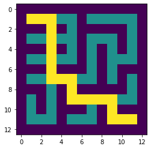

```python
R = copy.deepcopy(M_test)

def travel_chemin(M,C):
    for coords in C:
        a,b = coords
        M[a][b] = 2

travel_chemin(R,C)
plt.imshow(R)
```

Encore une fois on forme enfin notre sandwich :

```python
def solve_square_maze(start,end,M):
    N = copy.deepcopy(M)
    travel_maze_for_distance(start,end,N)
    C = get_chemin(start,end,N)
    N = copy.deepcopy(M)
    travel_chemin(N,C)
    return N
```

```
CPU times: user 41.7 ms, sys: 292 µs, total: 42 ms
Wall time: 40.9 ms
```

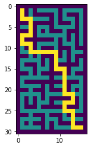

```python
%%time

#plt.imshow(M2)
startM2 = (1,1)
endM2 = (len(M2)-2,len(M2[0])-2)
N2 = solve_square_maze(startM2,endM2,M2)
plt.imshow(N2)
```

## 3.Autre design de labyrinthe

On va rapidement s'intéresser à un autre design de labyrinthe, il y a une manière meilleure pour générer ces labyrinthes (que l'on utilisera pour les cirulaires) mais nous allons simplement convertir les labyrinthes précédent.

On va utiliser un design avec des murs fins, comme ci dessous. D'abord quelques tests :

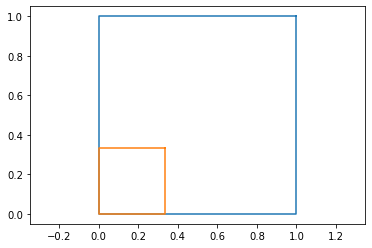

```python
carre = np.array([[1,0,0,1,1],[1,1,0,0,1]])

plt.plot(carre[0,:],carre[1,:])
plt.plot(carre[0,:]/3,carre[1,:]/3)
plt.axes().set_aspect('equal', 'datalim')
```

On utilisera un labyrinthe que l'on a créer précédemment.

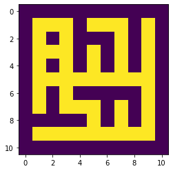

```python
T = create_square_maze(11,11)
plt.imshow(T)
```

```python
carr_sep_height = len(T)//2
carr_sep_width = len(T[0])//2
```

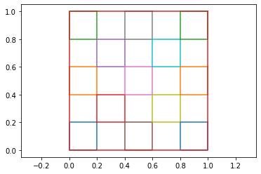

```python
for i in range(carr_sep_height):
    for j in range(carr_sep_width):
        if (i+j)%2 == 0:
            plt.plot((carre[0,:]+i)/carr_sep_height,(carre[1,:]+j)/carr_sep_width)


plt.plot(carre[0,:],carre[1,:])
plt.axes().set_aspect('equal', 'datalim')
```

On va synthétiser ces testes en une fonction de traçage de liaison, qui nous servira à tracer nos murs

```python
def plt_maze_liaison(liaison):
    ((a,b),(i,j)) = liaison
    if a == i:
        plt.plot(
            [max(b,j)/carr_sep_width,max(b,j)/carr_sep_width],
            [i/carr_sep_height,(i+1)/carr_sep_height],
            color='black'
        )
    else:
        plt.plot(
            [j/carr_sep_width,(j+1)/carr_sep_width],
            [max(a,i)/carr_sep_height,max(a,i)/carr_sep_height],
            color='black'
        )
```

Puis comme précédemment où nous prenions tous nos murs, là nous prenons toutes nos liaisons (c'est à dire un couple de coordonnées qui représentent les 2 cases liées) qui représentent nos murs.

```python
def get_liaisons(M):
    LI = []
    for i in range(1,len(M)-1):
        for j in range(1+(i%2),len(M[0])-1,2):
            if M[i][j] == 0:
                if i%2 == 1:
                    LI.append(((i//2,j//2),(i//2,(j//2)-1)))
                else:
                    LI.append(((i//2,j//2),((i//2)-1,j//2)))
    return LI

LI = get_liaisons(T)
print(np.array(LI))
```

```
[[[0 2]
  [0 1]]

 [[0 4]
  [0 3]]

 [[1 2]
  [0 2]]

 [[1 2]
  [1 1]]

 [[1 3]
  [1 2]]

 [[1 4]
  [1 3]]

 [[3 2]
  [2 2]]

 [[3 3]
  [2 3]]

 [[3 1]
  [3 0]]

 [[3 3]
  [3 2]]

 [[3 4]
  [3 3]]

 [[4 0]
  [3 0]]

 [[4 1]
  [3 1]]]
```

Finalement on affiche ces murs.

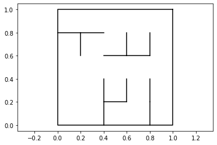

```python
for liaison in LI:
    plt_maze_liaison(liaison)

plt.plot(carre[0,:],carre[1,:], color='black')
plt.axes().set_aspect('equal', 'datalim')
```

Plutôt concluant mais pas aussi propre que :

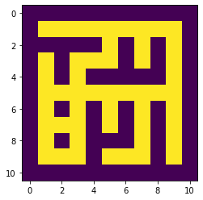

```python
T.reverse()
plt.imshow(T)
```